# EDA_Project

Rahman Rahimi

04 April 2018

| Lending Club Loan Data by Rahman Rahimi |
| --- |
| ======================================================== |

```r
# Load the Data
loan <- read.csv("loan.csv")
head(loan)
```

```r
tble <- tbl_df(loan)
```

# Univariate Plots Section

In this section, we perform some preliminary exploration of our dataset. we run some summaries of the data and create univariate plots to understand the structure of the individual variables in our dataset.

```r
glimpse(tble)
```

```
## Observations: 887,379
## Variables: 74
## $ id                          <int> 1077501, 1077430, 1077175, 1076863...
## $ member_id                   <int> 1296599, 1314167, 1313524, 1277178...
## $ loan_amnt                   <dbl> 5000, 2500, 2400, 10000, 3000, 500...
## $ funded_amnt                 <dbl> 5000, 2500, 2400, 10000, 3000, 500...
## $ funded_amnt_inv             <dbl> 4975.00, 2500.00, 2400.00, 10000.0...
## $ term                        <fct>  36 months,  60 months,  36 months...
## $ int_rate                    <dbl> 10.65, 15.27, 15.96, 13.49, 12.69,...
## $ installment                 <dbl> 162.87, 59.83, 84.33, 339.31, 67.7...
## $ grade                       <fct> B, C, C, C, B, A, C, E, F, B, C, B...
## $ sub_grade                   <fct> B2, C4, C5, C1, B5, A4, C5, E1, F2...
## $ emp_title                   <fct> , Ryder, , AIR RESOURCES BOARD, Un...
## $ emp_length                  <fct> 10+ years, < 1 year, 10+ years, 10...
## $ home_ownership              <fct> RENT, RENT, RENT, RENT, RENT, RENT...
```

[output cut: 61 more lines]

```r
df <- tble[, colSums(is.na(tble)) < length(tble)/2]
head(df)
```

```
## # A tibble: 6 x 50
##        id member_id loan_amnt funded_amnt funded_amnt_inv term    int_rate
##     <int>     <int>     <dbl>       <dbl>           <dbl> <fct>      <dbl>
## 1 1077501   1296599      5000        5000            4975 " 36 m~    10.6
## 2 1077430   1314167      2500        2500            2500 " 60 m~    15.3
## 3 1077175   1313524      2400        2400            2400 " 36 m~    16.0
## 4 1076863   1277178     10000       10000           10000 " 36 m~    13.5
## 5 1075358   1311748      3000        3000            3000 " 60 m~    12.7
## 6 1075269   1311441      5000        5000            5000 " 36 m~     7.90
## # ... with 43 more variables: installment <dbl>, grade <fct>,
## #   sub_grade <fct>, emp_title <fct>, emp_length <fct>,
## #   home_ownership <fct>, annual_inc <dbl>, verification_status <fct>,
## #   issue_d <fct>, loan_status <fct>, pymnt_plan <fct>, url <fct>,
## #   desc <fct>, purpose <fct>, title <fct>, zip_code <fct>,
## #   addr_state <fct>, dti <dbl>, delinq_2yrs <dbl>,
## #   earliest_cr_line <fct>, inq_last_6mths <dbl>, open_acc <dbl>,
## #   pub_rec <dbl>, revol_bal <dbl>, total_acc <dbl>,
## #   initial_list_status <fct>, out_prncp <dbl>, out_prncp_inv <dbl>,
## #   total_pymnt <dbl>, total_pymnt_inv <dbl>, total_rec_prncp <dbl>,
## #   total_rec_int <dbl>, total_rec_late_fee <dbl>, recoveries <dbl>,
## #   collection_recovery_fee <dbl>, last_pymnt_d <fct>,
## #   last_pymnt_amnt <dbl>, next_pymnt_d <fct>, last_credit_pull_d <fct>,
## #   policy_code <dbl>, application_type <fct>,
## #   verification_status_joint <fct>, acc_now_delinq <dbl>
```

We first remove the columns that more than 50% of values are NaNs. As you can see from the table above, we have 50 columns remaining. Let’s focus on these columns over the course of our EDA.

```r
factor_vars <- df[, sapply(df, is.factor)]
head(factor_vars)
```

```r
numerical_vars <- df[, sapply(df, is.numeric)]
head(numerical_vars)
```

Now, I have devide the entire dataset into 2 seperate ones, one for numeric columns and one for factor columns. The tables above show a head of each of these 2 newly created dataframes.

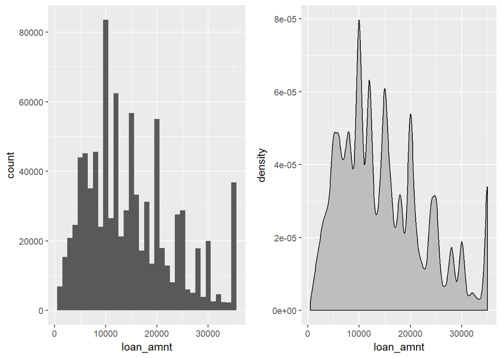

```r
p1 <- ggplot(data = df, aes(loan_amnt)) + geom_histogram(binwidth = 1000)
p2 <- ggplot(data = df, aes(loan_amnt)) + geom_density(fill = "gray")
grid.arrange(p1, p2, ncol = 2)
```

> Above, we can see the distribution of Loan Amount using 2 different plots.

```r
summary(df$loan_amnt)
```

```
##    Min. 1st Qu.  Median    Mean 3rd Qu.    Max.
##     500    8000   13000   14755   20000   35000
```

```r
loan_stat_df <- subset(df, !is.na(df$loan_status)) %>% group_by(loan_status) %>%
    summarise(Number = n())
loan_stat_df
```

```
## # A tibble: 10 x 2
##    loan_status                                         Number
##    <fct>                                                <int>
##  1 Charged Off                                          45248
##  2 Current                                             601779
##  3 Default                                               1219
##  4 Does not meet the credit policy. Status:Charged Off    761
##  5 Does not meet the credit policy. Status:Fully Paid    1988
##  6 Fully Paid                                          207723
##  7 In Grace Period                                       6253
##  8 Issued                                                8460
##  9 Late (16-30 days)                                     2357
## 10 Late (31-120 days)                                   11591
```

Let us have a look at the Loans’ Status. About 600 thousand loans are still current. About 200 thousand are fully paid and about 45 thousand loans are charged off.

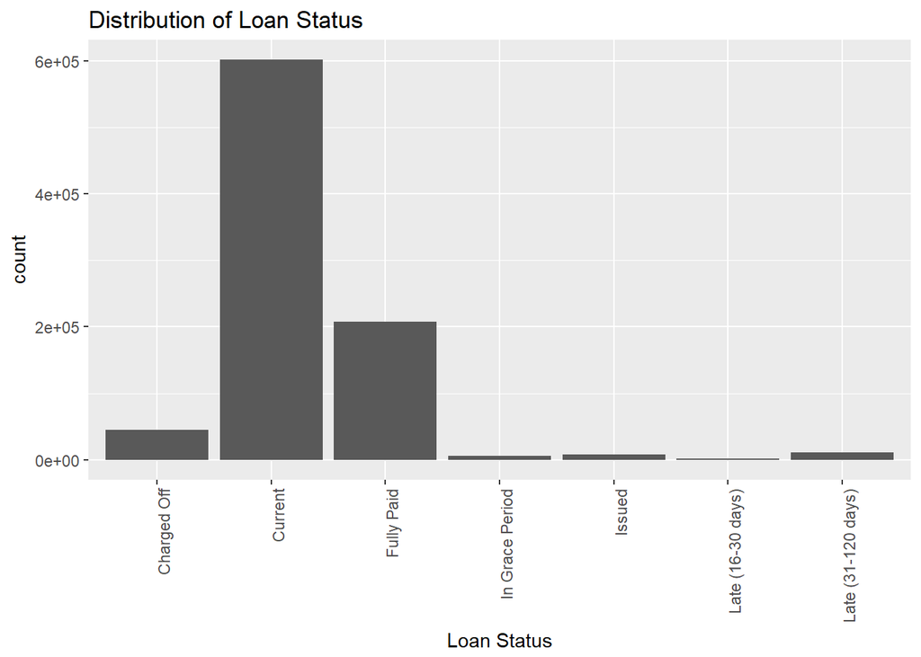

```r
dataset.new <- filter(df, !loan_status %in% c("Does not meet the credit policy. Status:Charged Off",
    "Does not meet the credit policy. Status:Fully Paid", "Default"))
ggplot(data = dataset.new, aes(loan_status)) + geom_bar(position = "dodge") +
    labs(x = "Loan Status", title = "Distribution of Loan Status") + theme(axis.text.x = element_text(angle = 90,
    hjust = 1))
```

# Univariate Analysis

- **What is/are the main feature(s) of interest in your dataset?**

A number of columns with Factor type and a the rest are continous or discrete form of numerical values. Among the numeric fields, the Loan Amount, Annual Income, Interest Rate are of particular interest.Of all the categorical fields (Factors), Home ownership, Loan Status, Loan Grade, Term, Verification Status are interesting.

- **Did you create any new variables from existing variables in the dataset?**

- **Of the features you investigated, were there any unusual distributions? Did you perform any operations on the data to tidy, adjust, or change the form of the data? If so, why did you do this?**

As we mentioned before, there are a number of columns with so many NaNs that could not be helpfu, so we decided to remove them.

# Bivariate and Multivariate Plots Section

- **Based on what you saw in the univariate plots, what relationships between variables might be interesting to look at in this section?**
- I was particularly interested in the relationship between `loan amount` and the following fields:
- Home Ownership
- Employment Length
- Loan Grade
- Loan Status
- Purpose
- Interest Rate
- Annula Income
- Income-to-Loan-ratio
- Verification Status Below, let us take a deeper look at these relationships:

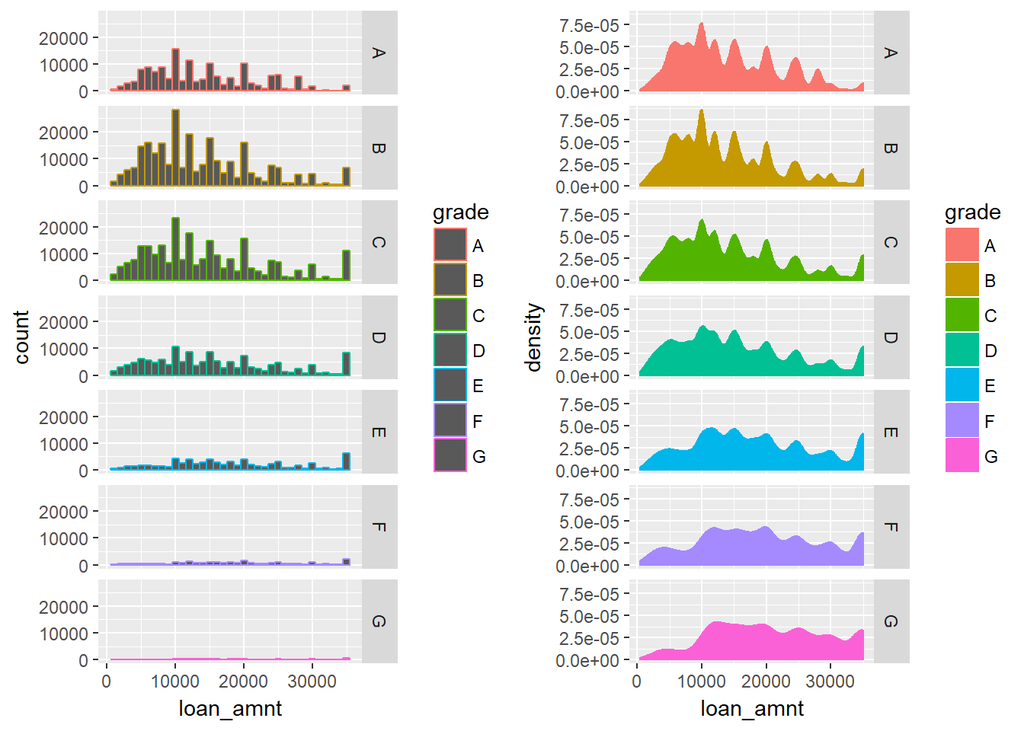

```r
p1 <- ggplot(data = df, aes(loan_amnt, color = grade)) + geom_histogram(binwidth = 1000) +
    facet_grid(grade ~ .)
p2 <- ggplot(data = df, aes(loan_amnt, color = grade, fill = grade)) + geom_density(binwidth = 1000) +
    facet_grid(grade ~ .)
grid.arrange(p1, p2, ncol = 2)
```

First, we look at the distribution of `Loan Amount` by Loan `Grade`. As you can see majority of the loans are in `Grades A, B, and C`. The interesting observation here was that as we move from grade A to Grade G, the loan amount distribution becomes more homogeneous.

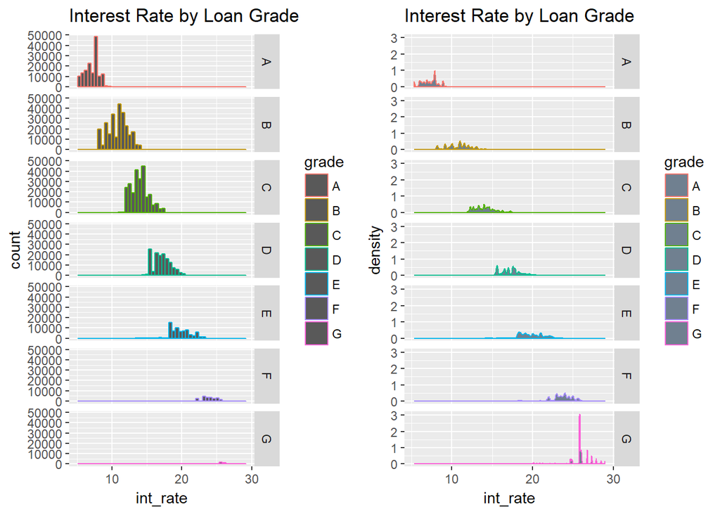

```r
l1 <- ggplot(data = subset(df, !is.na(int_rate)), aes(int_rate, color = grade)) +
    geom_histogram(bins = 50) + facet_grid(grade ~ .) + labs(title = "Interest Rate by Loan Grade")
l2 <- ggplot(data = subset(df, !is.na(int_rate)), aes(int_rate, color = grade)) +
    geom_density(fill = "SlateGray") + facet_grid(grade ~ .) + labs(title = "Interest Rate by Loan Grade")
grid.arrange(l1, l2, ncol = 2)
```

Now, the distribution of `interest rates` by `Grade` is also presented above, as you can see, the lowest interest rates apply to Grade A. So the more costly loans are in Grade G, F, E.

I am so curious to know to whome these good loans (Grade A) are granted and what kind of obvious difference could be detected between good grades and bad grades loan holders.

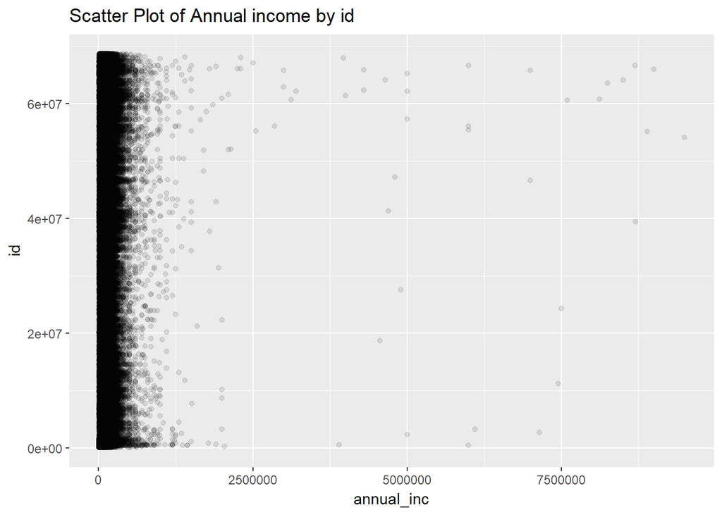

```r
ggplot(data = subset(df, !is.na(annual_inc)), aes(x = annual_inc, y = id)) +
    geom_point(alpha = 1/10, position = position_jitter(h = 0)) + labs(title = "Scatter Plot of Annual income by id")
```

The Scatter plot below shows the `self reported annual income` of all applicants. Obviously there are so many outliers that could be due to inputting error or some other reasons.

## finding outliers

```r
annual_inc.na <- subset(df, !is.na(annual_inc))

q3 <- quantile(annual_inc.na$annual_inc, 0.75)
q1 <- quantile(annual_inc.na$annual_inc, 0.25)
iqr.annual_inc <- (q3 - q1)
range <- (q3 + 1.5 * iqr.annual_inc)


annual_inc_new <- annual_inc.na %>% filter(annual_inc < range)
```

We calculated the `IQR (Interquartile Range)` and decided to remove the outliers from the analysis.we use the common measure of 1.5 X IQR beyond 3rd quartile as the outliers.

```r
summary(annual_inc_new$annual_inc)
```

```
##    Min. 1st Qu.  Median    Mean 3rd Qu.    Max.
##       0   45000   62000   67502   85000  157471
```

now we have removed the outliers and show the summary of the new data set above:

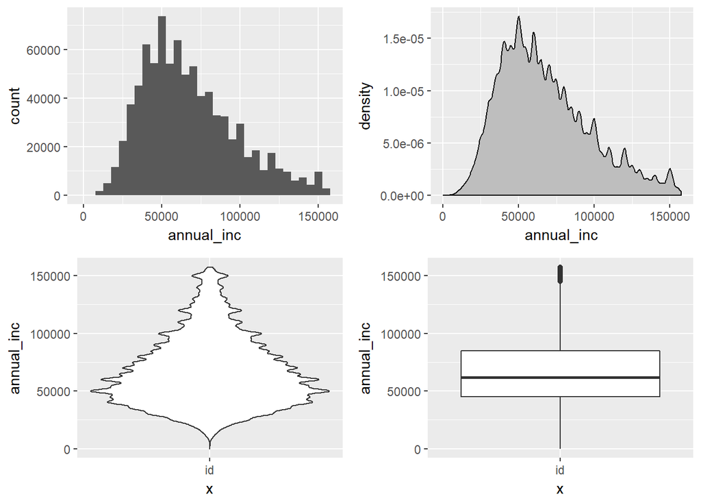

```r
l1 <- ggplot(data = annual_inc_new, aes(annual_inc)) + geom_histogram(binwidth = 5000)
l2 <- ggplot(data = annual_inc_new, aes(annual_inc)) + geom_density(fill = "gray")
l3 <- ggplot(data = annual_inc_new, aes(y = annual_inc, x = "id")) + geom_violin(scale = "area")
l4 <- ggplot(data = annual_inc_new, aes(y = annual_inc, x = "id")) + geom_boxplot(scale = "area")
grid.arrange(l1, l2, l3, l4, nrow = 2, ncol = 2)
```

Having removed the outliers, now we drew the same plots for Annual Income to get a better picture of the income of the customers.

## Creating New Variables

**we are going to create a new variable called `Income_to_loan_ratio` below:**

```r
annual_inc_new$Income_to_loan_ratio <- annual_inc_new$annual_inc/annual_inc_new$loan_amnt
```

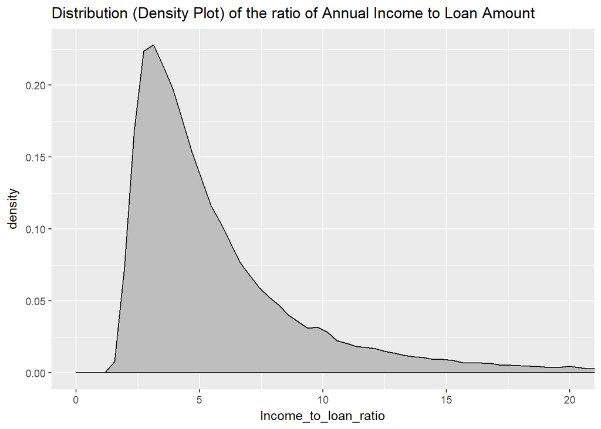

```r
ggplot(data = annual_inc_new, aes(Income_to_loan_ratio)) + geom_density(fill = "gray") +
    coord_cartesian(xlim = c(0, 20)) + labs(title = "Distribution (Density Plot) of the ratio of Annual Income to Loan Amount")
```

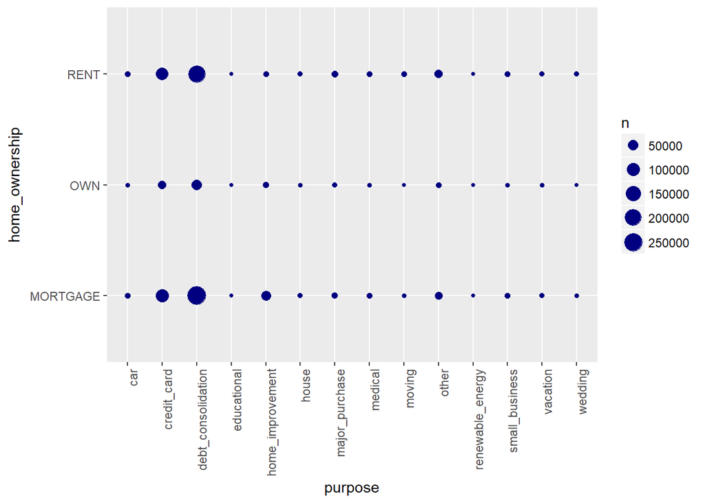

```r
ggplot(data = subset(df, !home_ownership %in% c("ANY", "NONE", "OTHER")), aes(y = home_ownership,
    purpose)) + geom_count(color = "Navy") + theme(axis.text.x = element_text(angle = 90,
    hjust = 1))
```

**Let us have a look at the Home Ownership and Purpose of loans.**

The plot above, shows the number of loans grouped by the Home Ownership and the purpose of the loan. Debt Consolidation is by far the most common purpose of loans. But the porportion is different among different types of home ownership. For example, the vast majority of Mortgage holders need loans for Debt Consolidation and credit cards. People who own their homes either do not need or do not apply for a loan through this website. As you can see, it is very uncommon for the home owners to get loans to pay their credit cards debt compared to the ones who either rent or paying mortgage.

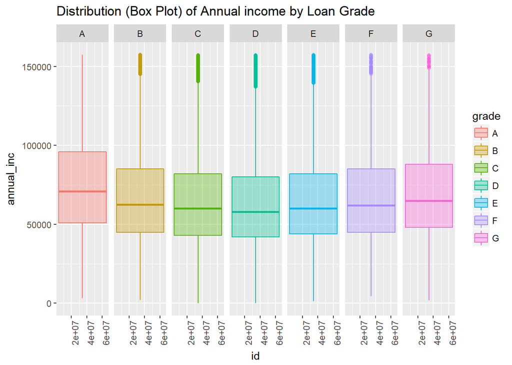

```r
ggplot(data = annual_inc_new, aes(y = annual_inc, x = id, fill = grade, color = grade)) +
    geom_boxplot(alpha = 1/3) + facet_grid(. ~ grade) + labs(title = "Distribution (Box Plot) of Annual income by Loan Grade") +
    theme(axis.text.x = element_text(angle = 90, hjust = 1))
```

Box plots of Annual Income by Loan Grade are shown above.Looking at the median line of the box plots, we see a downtrend from Grade A to D and then a slight uptrend towards G.The Grade D has the narrowest range among all other grades.

## Home Ownership

```r
df %>% filter(!is.na(home_ownership)) %>% filter(!home_ownership %in% c("OTHER",
    "NONE", "ANY")) %>% group_by(home_ownership) %>% summarise(mean_amnt_loan = mean(loan_amnt),
    mean_annual_inc = mean(annual_inc), n = n()) %>% ungroup() %>% arrange(desc(n))
```

```
## # A tibble: 3 x 4
##   home_ownership mean_amnt_loan mean_annual_inc      n
##   <fct>                   <dbl>           <dbl>  <int>
## 1 MORTGAGE                16375           85106 443557
## 2 RENT                    12871           63982 356117
## 3 OWN                     14223           68913  87470
```

Table above shows the average amount of loans and average annual income by different Home Ownership status. More than 443 thousand loans were granted to those with a mortgaged home, but only 87 thosand to those who own their home. A clear difference between the annual inmcome of those with different home ownership is also shown.

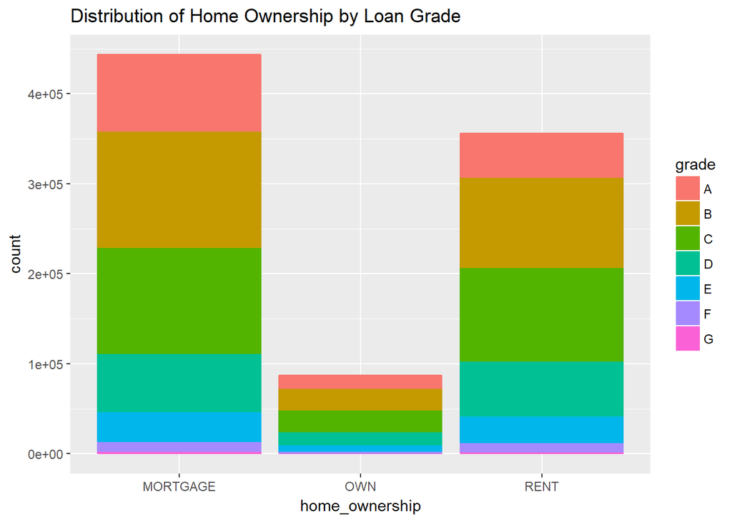

```r
ggplot(data = subset(df, (!is.na(home_ownership) & (!home_ownership %in% c("ANY",
    "NONE", "OTHER")))), aes(home_ownership, fill = grade, color = grade)) +
    geom_bar() + labs(title = "Distribution of Home Ownership by Loan Grade")
```

Here I brought the plot of Home Ownership by Loan Grade as a stacked bar chart. The majority of loans are granted to those with Mortgage and grade B and C are the most common ones.

## purpose of loan

```r
df %>% filter(!is.na(purpose)) %>% group_by(purpose) %>% summarise(mean_annual_inc = mean(annual_inc),
    mean_amnt_loan = mean(loan_amnt), n = n()) %>% ungroup() %>% arrange(desc(n))
```

```
## # A tibble: 14 x 4
##    purpose            mean_annual_inc mean_amnt_loan      n
##    <fct>                        <dbl>          <dbl>  <int>
##  1 debt_consolidation           73891          15428 524215
##  2 credit_card                  75098          15339 206182
##  3 home_improvement             90271          14321  51829
##  4 other                           NA           9889  42894
##  5 major_purchase               76700          11600  17277
##  6 small_business               89886          15420  10377
##  7 car                          67879           8882   8863
##  8 medical                      72163           9019   8540
##  9 moving                       68157           7892   5414
## 10 vacation                     66874           6290   4736
## 11 house                        80448          14798   3707
## 12 wedding                      69455          10469   2347
## 13 renewable_energy             75086           9948    575
## 14 educational                  51264           6616    423
```

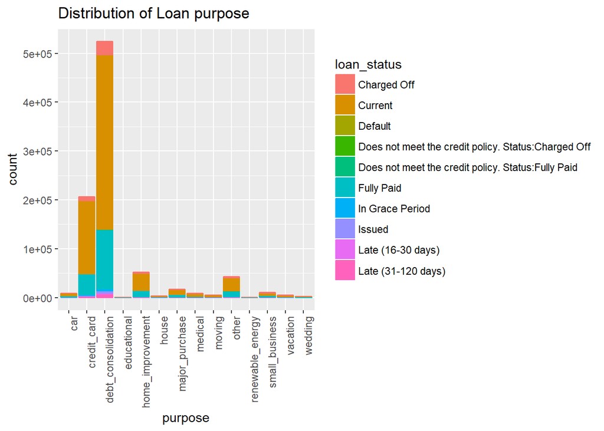

```r
ggplot(data = subset(df, !is.na(purpose)), aes(purpose, fill = loan_status,
    color = loan_status)) + geom_bar() + labs(title = "Distribution of Loan purpose") +
    theme(axis.text.x = element_text(angle = 90, hjust = 1))
```

Now let us have a look at what have happened to the loans with different purposes. The plot above, shows the distribution of of loan purposes by loan status.

```r
df %>% filter(!is.na(verification_status)) %>% group_by(verification_status) %>%
    summarise(mean_annual_inc = mean(annual_inc), mean_amnt_loan = mean(loan_amnt),
        n = n()) %>% ungroup() %>% arrange(verification_status)
```

```
## # A tibble: 3 x 4
##   verification_status mean_annual_inc mean_amnt_loan      n
##   <fct>                         <dbl>          <dbl>  <int>
## 1 Not Verified                     NA          11176 266750
## 2 Source Verified               78916          15500 329558
## 3 Verified                      78191          17193 291071
```

I am curious to know what is the average annual income and average loan amount granted based on the verification status. As we can see for those whose loans could not be verified, the average amount of loan is the lowest and if it was verified they got the highest amount of loan on average which is exactly what we can expect.

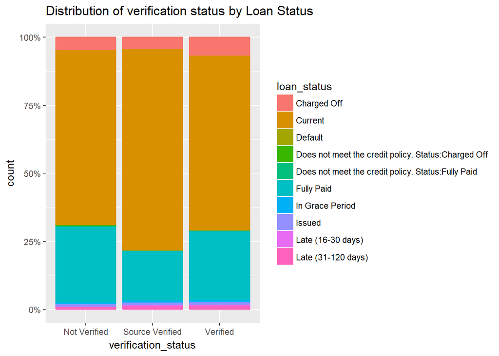

```r
ggplot(data = subset(df, !is.na(verification_status)), aes(verification_status,
    fill = loan_status, color = loan_status)) + geom_bar(position = "fill") +
    labs(title = "Distribution of verification status by Loan Status") + scale_y_continuous(labels = percent_format())
```

```r
df %>% filter(!is.na(grade)) %>% group_by(grade) %>% summarise(mean_annual_inc = mean(annual_inc),
    mean_amnt_loan = mean(loan_amnt), n = n()) %>% ungroup() %>% arrange(grade)
```

```
## # A tibble: 7 x 4
##   grade mean_annual_inc mean_amnt_loan      n
##   <fct>           <dbl>          <dbl>  <int>
## 1 A                  NA          14039 148202
## 2 B               75487          13643 254535
## 3 C               71537          14466 245860
## 4 D               69169          15460 139542
## 5 E               72119          17998  70705
## 6 F               73801          19139  23046
## 7 G               79905          20539   5489
```

Let us see what are the average amount of loans granted and the average annual income based on the loan grades. So the highest average amount of loans granted is on Grade G with about 5400 cases which is of course a very low number compared to say Grade B with more than 250 thousand cases. For grade B with the highest number of loans granted, the average amount of loan is $13642.

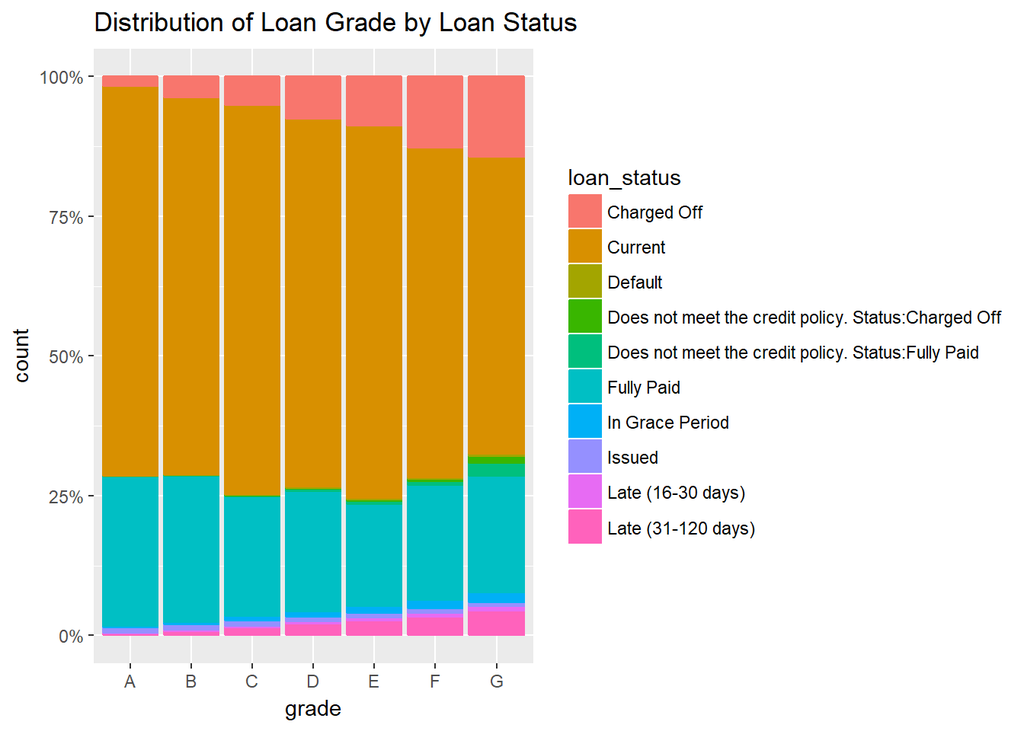

```r
ggplot(data = subset(df, !is.na(grade)), aes(grade, fill = loan_status, color = loan_status)) +
    geom_bar(position = "fill") + labs(title = "Distribution of Loan Grade by Loan Status") +
    scale_y_continuous(labels = percent_format())
```

another interesting plot is shown above, this distribution plot gives the percentage of loan status based on their grades. So, as we expect, grade G has the highest percentage of loans with “Charged off” status and it shows a steady downtrend as we move towards the better grades (A and B). Moreover, the same trend is evident for the late payments. For example the highest percentage of late payments are among the loans with grade G.

```r
df %>% filter(!is.na(loan_status)) %>% group_by(loan_status) %>% summarise(mean_annual_inc = mean(annual_inc),
    mean_amnt_loan = mean(loan_amnt), n = n()) %>% ungroup() %>% arrange(loan_status)
```

```
## # A tibble: 10 x 4
##    loan_status                       mean_annual_inc mean_amnt_loan      n
##    <fct>                                       <dbl>          <dbl>  <int>
##  1 Charged Off                                 65085          14556  45248
##  2 Current                                     76153          15242 601779
##  3 Default                                     66754          15194   1219
##  4 Does not meet the credit policy.~           69526           9527    761
##  5 Does not meet the credit policy.~              NA           8853   1988
##  6 Fully Paid                                  74162          13346 207723
##  7 In Grace Period                             76132          16006   6253
##  8 Issued                                      78318          15299   8460
##  9 Late (16-30 days)                           73279          15671   2357
## 10 Late (31-120 days)                          70021          15569  11591
```

## Creating Bins for Interest Rates, Loan Amounts, and Annual Income

```r
df <- transform(df, int_group = cut(int_rate, breaks = c(0, 7.5, 10, 12.5, 15,
    20), labels = c("0-7.5", "7.5-10", "10-12.5", "12.5-15", "15 and above")))

df <- transform(df, loan_amnt_group = cut(loan_amnt, breaks = c(0, 5000, 10000,
    15000, 20000, 25000, 40000), labels = c("0-5000", "5000-10000", "10000-15000",
    "15000-20000", "20000-25000", "25000 and above")))

df <- transform(df, ann_income_group = cut(annual_inc, breaks = c(0, 25000,
    50000, 75000, 1e+05, 1e+06), labels = c("0-25000", "25000-50000", "50000-75000",
    "75000-100000", "100000 and above")))
```

We just binned the Interest Rate, Loan Amount, and Annual income columns and converted them into Factor values.

## Correlation Analysis Using corrplot

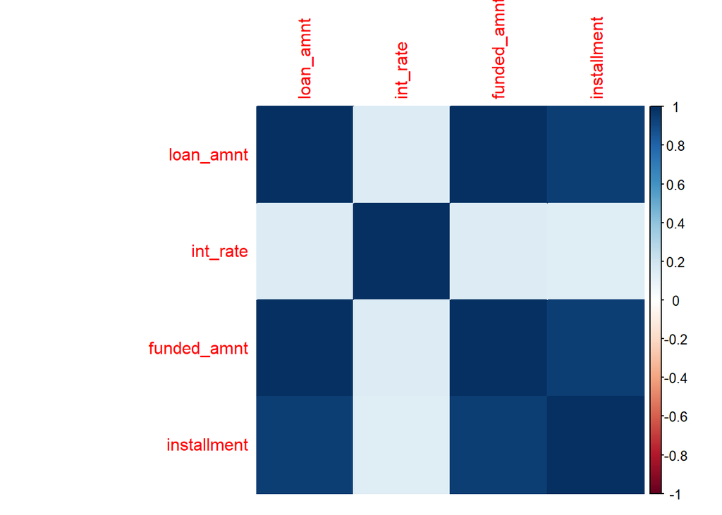

```r
new_list <- numerical_vars[c("loan_amnt", "int_rate", "funded_amnt", "installment")]
M <- cor(new_list)
corrplot(M, method = "color")
```

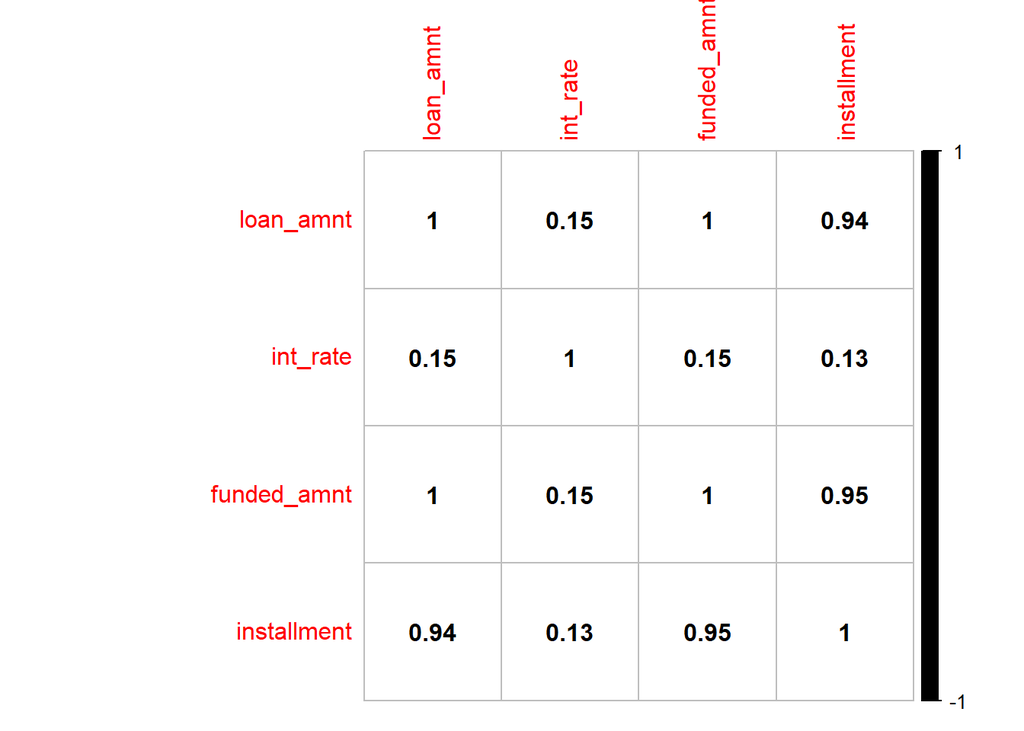

```r
corrplot(M, method = "number", col = "black")
```

Above, we have provided the correlation plots for 4 numeric columns of: ‘loan_amnt’, ‘int_rate’, ‘funded_amnt’, ‘installment’.

**converting Issue_d column to date Format:**

```r
df$dates <- dmy(paste0("01-", df$issue_d))
df_amount_grade <- df %>% group_by(dates, grade) %>% summarise(Loan_Amount = sum(loan_amnt),
    n = n())
```

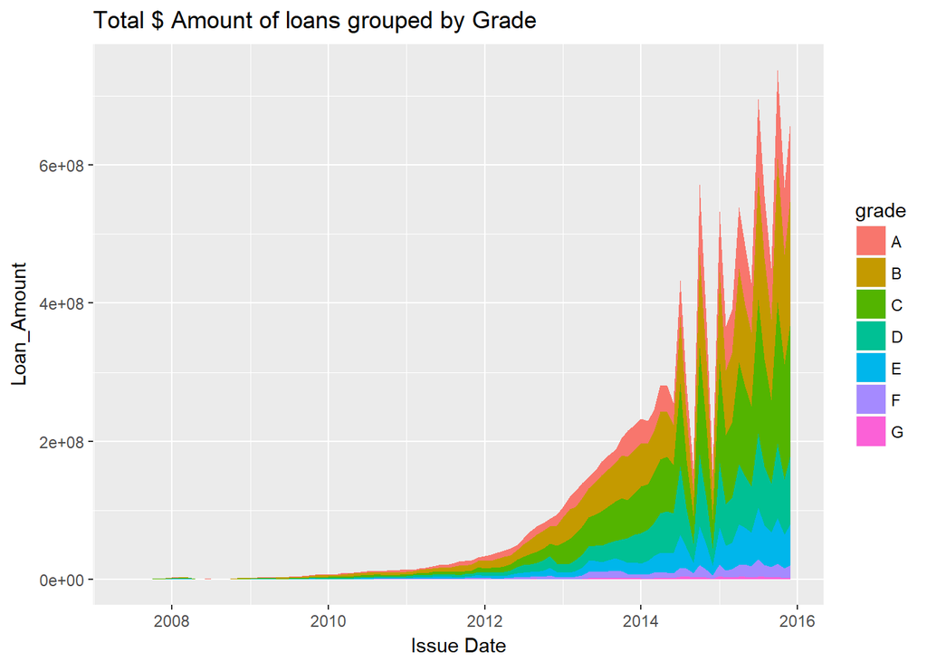

```r
ggplot(df_amount_grade, aes(x = dates, y = Loan_Amount)) + geom_area(aes(fill = grade)) +
    xlab("Issue Date") + labs(title = "Total $ Amount of loans grouped by Grade")
```

let us investigate how the total amount of loans has changed over the time. The plot above shows the total dollar amount of loans granted from 2008 untill 2016.There has been some spikes and some very sharp declines that might be due to some technical problem or lack of data or perhaps some seasonal trend exisiting in the market.

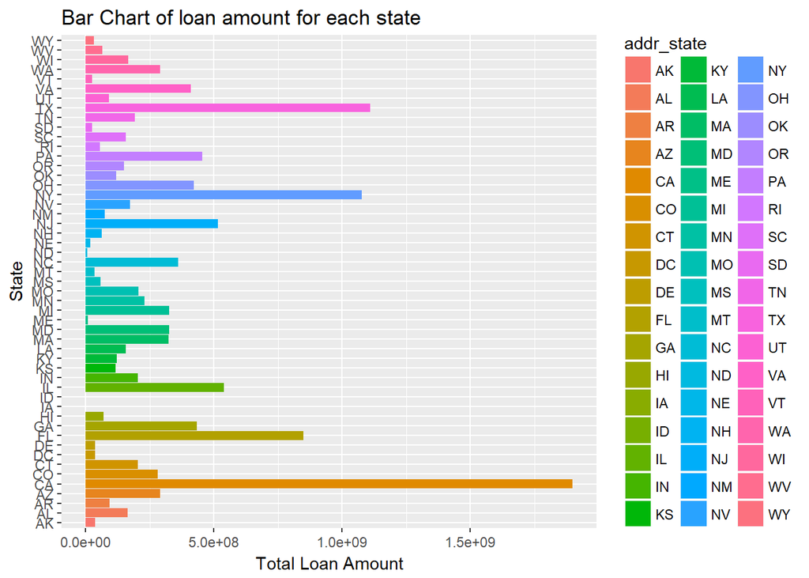

```r
ggplot(data = subset(df, !is.na(addr_state)), aes(x = addr_state, y = loan_amnt,
    fill = addr_state)) + stat_summary(fun.y = "sum", geom = "bar") + coord_flip() +
    labs(y = "Total Loan Amount", x = "State", title = "Bar Chart of loan amount for each state")
```

The amount of loans granted by state is presented above. California is by far the first state in terms of the total amount of loans. ——

# Bivariate and Multivariate Analysis

- **The relationships I have observed**

# Final Plots and Summary

### Plot One

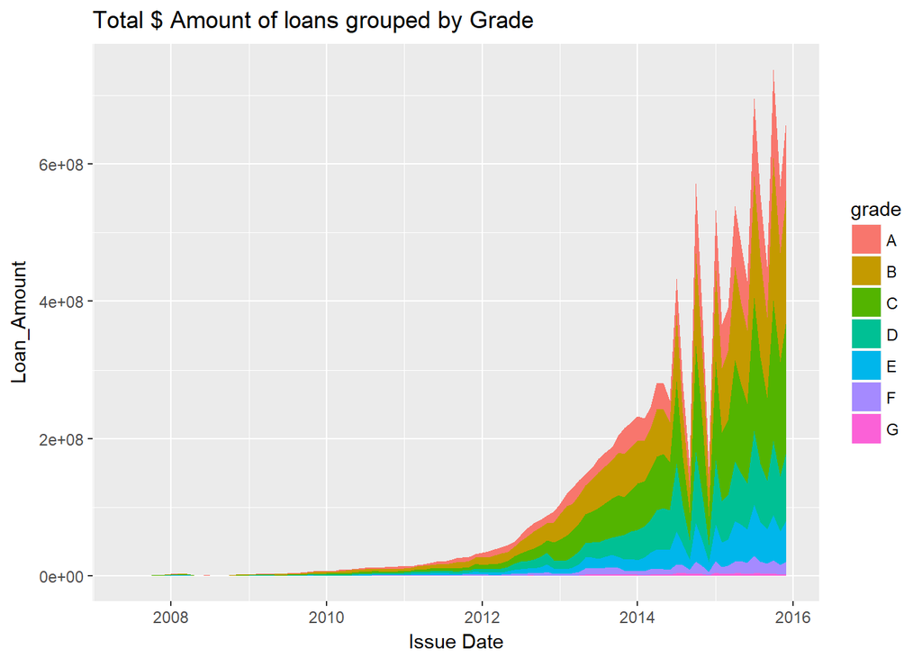

```r
ggplot(df_amount_grade, aes(x = dates, y = Loan_Amount)) + geom_area(aes(fill = grade)) +
    xlab("Issue Date") + labs(title = "Total $ Amount of loans grouped by Grade")
```

### Description One

The Total amount of loans has grown significantly since 2010, there was a period of stagnation from 2008 to 2010 before it took some momentum. Grade B and C are the most common loan grades and have become more so after 2015. There are a few unusual spikes folowed by sharp declines in late 2014 that need a more comprehensive analysis to figure out the reason behind it. All in all the growth looks impressive and there does not seem to be any sign of weakness.

### Plot Two

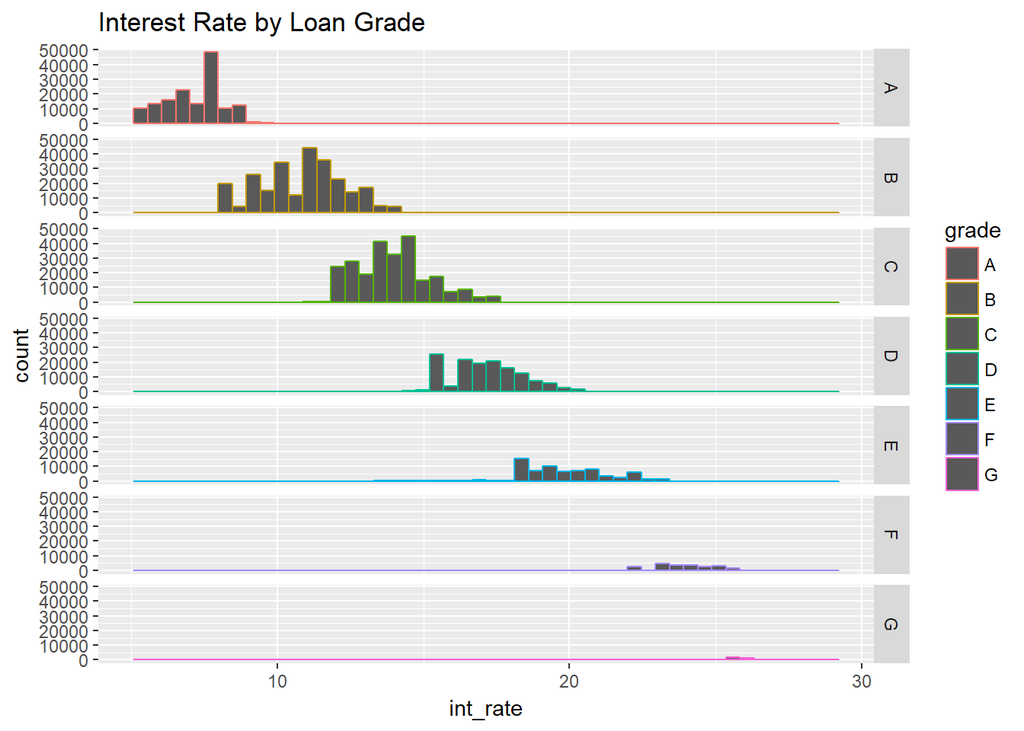

```r
ggplot(data = subset(df, !is.na(int_rate)), aes(int_rate, color = grade)) +
    geom_histogram(bins = 50) + facet_grid(grade ~ .) + labs(title = "Interest Rate by Loan Grade")
```

### Description Two

The plot shows the disctribution of Interest Rate by Loan Grade. It is kind of obvious that there are differences between grades in terms of interest rates. The grades A-C have significantly lower interest rates.

### Plot Three

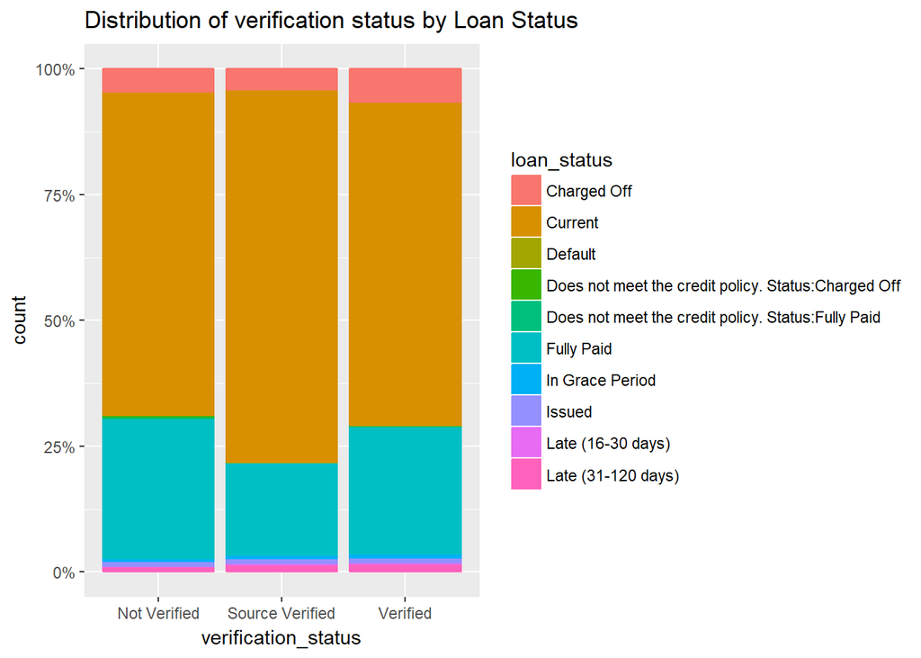

```r
ggplot(data = subset(df, !is.na(verification_status)), aes(verification_status,
    fill = loan_status, color = loan_status)) + geom_bar(position = "fill") +
    labs(title = "Distribution of verification status by Loan Status") + scale_y_continuous(labels = percent_format())
```

### Description Three

As I previously mentioned, this plot shows a rather interesting observation. The “Verified” category has shown a higher percentage of “Charged off” loans compared to the other 2 categories. What we would have expected before any deep analysis, could be the verified loans have a lower risk of default, but it does not seem to be the case. Another important fact from this chart that I would like to point out is that the verified category has higher percentage of “LATE”s as well which is also counter-intuitive.

# Reflection